# SQ 021

## Shared Qs (021)

#### Question

1. Does the complex number $z=3+6i$ solve the equation below?

   $$z^2-6z+47=0$$
   1. Yes
   2. No

#### Solution

#### Question

2. Does the complex number $z=5-3i$ solve the equation below?

   $$z^2-10z+34=0$$
   1. Yes
   2. No

#### Solution

#### Question

3. Does the complex number $z=-2-8i$ solve the equation below?

   $$z^2+3z+72=0$$
   1. Yes
   2. No

#### Solution

#### Question

4. Does the complex number $z=-7-9i$ solve the equation below?

   $$z^2+15z+127=0$$
   1. Yes
   2. No

#### Solution

#### Question

5. Does the complex number $z=-2-4i$ solve the equation below?

   $$z^2+4z+20=0$$
   1. Yes
   2. No

#### Solution

#### Question

6. Does the complex number $z=-4-6i$ solve the equation below?

   $$z^2+9z+50=0$$
   1. Yes
   2. No

#### Solution

#### Question

7. Does the complex number $z=6-8i$ solve the equation below?

   $$z^2-12z+104=0$$
   1. Yes
   2. No

#### Solution

#### Question

8. Does the complex number $z=8-3i$ solve the equation below?

   $$z^2-16z+73=0$$
   1. Yes
   2. No

#### Solution

#### Question

9. Does the complex number $z=3+9i$ solve the equation below?

   $$z^2-6z+82=0$$
   1. Yes
   2. No

#### Solution

#### Question

10. Does the complex number $z=-7-8i$ solve the equation below?

    $$z^2+14z+113=0$$
    1. Yes
    2. No

#### Solution

#### Question

11. A student has taken 6 exams and gotten an average of 72. What score does the student need on the next exam to bring the average to 75? (All exams are equally weighted in the average.)

#### Solution

#### Question

12. A student has taken 3 exams and gotten an average of 72. What score does the student need on the next exam to bring the average to 75? (All exams are equally weighted in the average.)

#### Solution

#### Question

13. A student has taken 5 exams and gotten an average of 66.6. What score does the student need on the next exam to bring the average to 70? (All exams are equally weighted in the average.)

#### Solution

#### Question

14. A student has taken 5 exams and gotten an average of 66. What score does the student need on the next exam to bring the average to 70? (All exams are equally weighted in the average.)

#### Solution

#### Question

15. A student has taken 4 exams and gotten an average of 63.5. What score does the student need on the next exam to bring the average to 70? (All exams are equally weighted in the average.)

#### Solution

#### Question

16. A student has taken 4 exams and gotten an average of 75.5. What score does the student need on the next exam to bring the average to 80? (All exams are equally weighted in the average.)

#### Solution

#### Question

17. A student has taken 5 exams and gotten an average of 82.2. What score does the student need on the next exam to bring the average to 85? (All exams are equally weighted in the average.)

#### Solution

#### Question

18. A student has taken 7 exams and gotten an average of 62. What score does the student need on the next exam to bring the average to 65? (All exams are equally weighted in the average.)

#### Solution

#### Question

19. A student has taken 4 exams and gotten an average of 61.5. What score does the student need on the next exam to bring the average to 65? (All exams are equally weighted in the average.)

#### Solution

#### Question

20. A student has taken 3 exams and gotten an average of 61. What score does the student need on the next exam to bring the average to 70? (All exams are equally weighted in the average.)

#### Solution

#### Question

21. A lifeguard wants to get to a struggling swimmer as soon as possible. The lifeguard can run along the beach at 3.7 m/s and swim at 1.6 m/s. The lifeguard will run $x$ meters and swim $\sqrt{(170-x)^2+20^2}$ meters.

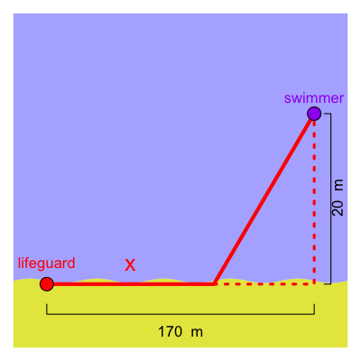

    Thus, the time is a function of $x$.

    $$t(x) ~=~ \frac{x}{3.7} + \frac{\sqrt{(170-x)^2+20^2}}{1.6}$$

    Find the value of $x$ (in meters) that minimizes the amount of time. The tolerance is $\pm 0.1$ meters.

#### Solution

#### Question

22. A lifeguard wants to get to a struggling swimmer as soon as possible. The lifeguard can run along the beach at 3 m/s and swim at 0.9 m/s. The lifeguard will run $x$ meters and swim $\sqrt{(130-x)^2+30^2}$ meters.

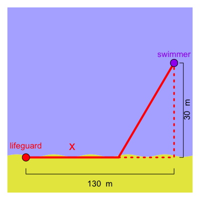

    Thus, the time is a function of $x$.

    $$t(x) ~=~ \frac{x}{3} + \frac{\sqrt{(130-x)^2+30^2}}{0.9}$$

    Find the value of $x$ (in meters) that minimizes the amount of time. The tolerance is $\pm 0.1$ meters.

#### Solution

#### Question

23. A lifeguard wants to get to a struggling swimmer as soon as possible. The lifeguard can run along the beach at 4 m/s and swim at 1.8 m/s. The lifeguard will run $x$ meters and swim $\sqrt{(290-x)^2+10^2}$ meters.

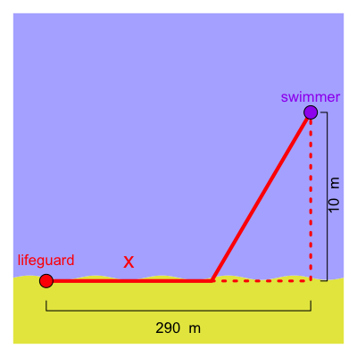

    Thus, the time is a function of $x$.

    $$t(x) ~=~ \frac{x}{4} + \frac{\sqrt{(290-x)^2+10^2}}{1.8}$$

    Find the value of $x$ (in meters) that minimizes the amount of time. The tolerance is $\pm 0.1$ meters.

#### Solution

#### Question

24. A lifeguard wants to get to a struggling swimmer as soon as possible. The lifeguard can run along the beach at 2.1 m/s and swim at 1.2 m/s. The lifeguard will run $x$ meters and swim $\sqrt{(180-x)^2+60^2}$ meters.

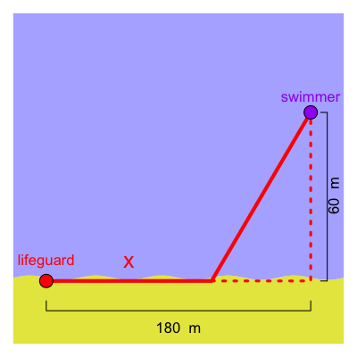

    Thus, the time is a function of $x$.

    $$t(x) ~=~ \frac{x}{2.1} + \frac{\sqrt{(180-x)^2+60^2}}{1.2}$$

    Find the value of $x$ (in meters) that minimizes the amount of time. The tolerance is $\pm 0.1$ meters.

#### Solution

#### Question

25. A lifeguard wants to get to a struggling swimmer as soon as possible. The lifeguard can run along the beach at 3.5 m/s and swim at 1.2 m/s. The lifeguard will run $x$ meters and swim $\sqrt{(300-x)^2+60^2}$ meters.

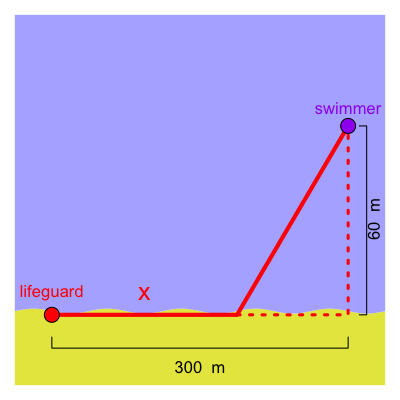

    Thus, the time is a function of $x$.

    $$t(x) ~=~ \frac{x}{3.5} + \frac{\sqrt{(300-x)^2+60^2}}{1.2}$$

    Find the value of $x$ (in meters) that minimizes the amount of time. The tolerance is $\pm 0.1$ meters.

#### Solution

#### Question

26. A lifeguard wants to get to a struggling swimmer as soon as possible. The lifeguard can run along the beach at 3.7 m/s and swim at 1 m/s. The lifeguard will run $x$ meters and swim $\sqrt{(250-x)^2+50^2}$ meters.

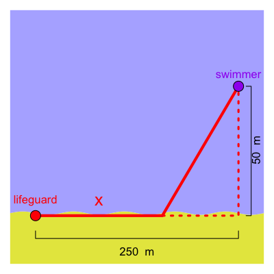

    Thus, the time is a function of $x$.

    $$t(x) ~=~ \frac{x}{3.7} + \frac{\sqrt{(250-x)^2+50^2}}{1}$$

    Find the value of $x$ (in meters) that minimizes the amount of time. The tolerance is $\pm 0.1$ meters.

#### Solution

#### Question

27. A lifeguard wants to get to a struggling swimmer as soon as possible. The lifeguard can run along the beach at 3.7 m/s and swim at 1.8 m/s. The lifeguard will run $x$ meters and swim $\sqrt{(280-x)^2+40^2}$ meters.

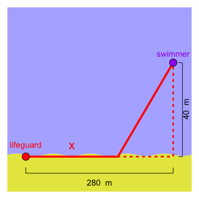

    Thus, the time is a function of $x$.

    $$t(x) ~=~ \frac{x}{3.7} + \frac{\sqrt{(280-x)^2+40^2}}{1.8}$$

    Find the value of $x$ (in meters) that minimizes the amount of time. The tolerance is $\pm 0.1$ meters.

#### Solution

#### Question

28. A lifeguard wants to get to a struggling swimmer as soon as possible. The lifeguard can run along the beach at 3.9 m/s and swim at 1.3 m/s. The lifeguard will run $x$ meters and swim $\sqrt{(240-x)^2+30^2}$ meters.

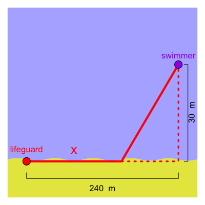

    Thus, the time is a function of $x$.

    $$t(x) ~=~ \frac{x}{3.9} + \frac{\sqrt{(240-x)^2+30^2}}{1.3}$$

    Find the value of $x$ (in meters) that minimizes the amount of time. The tolerance is $\pm 0.1$ meters.

#### Solution

#### Question

29. A lifeguard wants to get to a struggling swimmer as soon as possible. The lifeguard can run along the beach at 3.9 m/s and swim at 1.1 m/s. The lifeguard will run $x$ meters and swim $\sqrt{(170-x)^2+30^2}$ meters.

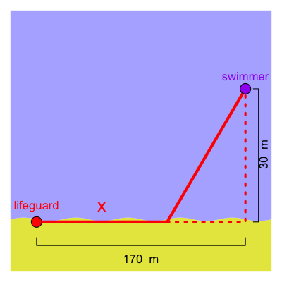

    Thus, the time is a function of $x$.

    $$t(x) ~=~ \frac{x}{3.9} + \frac{\sqrt{(170-x)^2+30^2}}{1.1}$$

    Find the value of $x$ (in meters) that minimizes the amount of time. The tolerance is $\pm 0.1$ meters.

#### Solution

#### Question

30. A lifeguard wants to get to a struggling swimmer as soon as possible. The lifeguard can run along the beach at 3.3 m/s and swim at 1.6 m/s. The lifeguard will run $x$ meters and swim $\sqrt{(240-x)^2+30^2}$ meters.

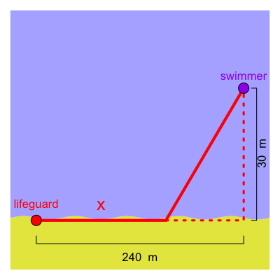

    Thus, the time is a function of $x$.

    $$t(x) ~=~ \frac{x}{3.3} + \frac{\sqrt{(240-x)^2+30^2}}{1.6}$$

    Find the value of $x$ (in meters) that minimizes the amount of time. The tolerance is $\pm 0.1$ meters.

#### Solution

#### Question

41. Below is a 2-way table expressing [joint probabilities](https://en.wikipedia.org/wiki/Joint_probability_distribution).

    |  | A | not A |
    | --- | --- | --- |
    | B | 33% | 42% |
    | not B | 11% | 14% |

    So,

    $$\begin{align}
    P(A \text{ and }B) &= 0.33 \\
    P(A \text{ and not }B) &= 0.11 \\
    P([\text{not }A] \text{ and }B) &= 0.42 \\
    P([\text{not }A] \text{ and [not }B]) &= 0.14 \\
    \end{align}$$

    Are events $A$ and $B$ independent?
    1. Yes, events A and B are independent.
    2. No, events A and B are dependent.

#### Solution

#### Question

42. Below is a 2-way table expressing [joint probabilities](https://en.wikipedia.org/wiki/Joint_probability_distribution).

    |  | A | not A |
    | --- | --- | --- |
    | B | 27% | 48% |
    | not B | 9% | 16% |

    So,

    $$\begin{align}
    P(A \text{ and }B) &= 0.27 \\
    P(A \text{ and not }B) &= 0.09 \\
    P([\text{not }A] \text{ and }B) &= 0.48 \\
    P([\text{not }A] \text{ and [not }B]) &= 0.16 \\
    \end{align}$$

    Are events $A$ and $B$ independent?
    1. Yes, events A and B are independent.
    2. No, events A and B are dependent.

#### Solution

#### Question

43. Below is a 2-way table expressing [joint probabilities](https://en.wikipedia.org/wiki/Joint_probability_distribution).

    |  | A | not A |
    | --- | --- | --- |
    | B | 7% | 13% |
    | not B | 28% | 52% |

    So,

    $$\begin{align}
    P(A \text{ and }B) &= 0.07 \\
    P(A \text{ and not }B) &= 0.28 \\
    P([\text{not }A] \text{ and }B) &= 0.13 \\
    P([\text{not }A] \text{ and [not }B]) &= 0.52 \\
    \end{align}$$

    Are events $A$ and $B$ independent?
    1. Yes, events A and B are independent.
    2. No, events A and B are dependent.

#### Solution

#### Question

44. Below is a 2-way table expressing [joint probabilities](https://en.wikipedia.org/wiki/Joint_probability_distribution).

    |  | A | not A |
    | --- | --- | --- |
    | B | 33% | 28% |
    | not B | 17% | 22% |

    So,

    $$\begin{align}
    P(A \text{ and }B) &= 0.33 \\
    P(A \text{ and not }B) &= 0.17 \\
    P([\text{not }A] \text{ and }B) &= 0.28 \\
    P([\text{not }A] \text{ and [not }B]) &= 0.22 \\
    \end{align}$$

    Are events $A$ and $B$ independent?
    1. Yes, events A and B are independent.
    2. No, events A and B are dependent.

#### Solution

#### Question

45. Below is a 2-way table expressing [joint probabilities](https://en.wikipedia.org/wiki/Joint_probability_distribution).

    |  | A | not A |
    | --- | --- | --- |
    | B | 19% | 16% |
    | not B | 31% | 34% |

    So,

    $$\begin{align}
    P(A \text{ and }B) &= 0.19 \\
    P(A \text{ and not }B) &= 0.31 \\
    P([\text{not }A] \text{ and }B) &= 0.16 \\
    P([\text{not }A] \text{ and [not }B]) &= 0.34 \\
    \end{align}$$

    Are events $A$ and $B$ independent?
    1. Yes, events A and B are independent.
    2. No, events A and B are dependent.

#### Solution

#### Question

46. Below is a 2-way table expressing [joint probabilities](https://en.wikipedia.org/wiki/Joint_probability_distribution).

    |  | A | not A |
    | --- | --- | --- |
    | B | 15% | 5% |
    | not B | 60% | 20% |

    So,

    $$\begin{align}
    P(A \text{ and }B) &= 0.15 \\
    P(A \text{ and not }B) &= 0.6 \\
    P([\text{not }A] \text{ and }B) &= 0.05 \\
    P([\text{not }A] \text{ and [not }B]) &= 0.2 \\
    \end{align}$$

    Are events $A$ and $B$ independent?
    1. Yes, events A and B are independent.
    2. No, events A and B are dependent.

#### Solution

#### Question

47. Below is a 2-way table expressing [joint probabilities](https://en.wikipedia.org/wiki/Joint_probability_distribution).

    |  | A | not A |
    | --- | --- | --- |
    | B | 30% | 49% |
    | not B | 10% | 11% |

    So,

    $$\begin{align}
    P(A \text{ and }B) &= 0.3 \\
    P(A \text{ and not }B) &= 0.1 \\
    P([\text{not }A] \text{ and }B) &= 0.49 \\
    P([\text{not }A] \text{ and [not }B]) &= 0.11 \\
    \end{align}$$

    Are events $A$ and $B$ independent?
    1. Yes, events A and B are independent.
    2. No, events A and B are dependent.

#### Solution

#### Question

48. Below is a 2-way table expressing [joint probabilities](https://en.wikipedia.org/wiki/Joint_probability_distribution).

    |  | A | not A |
    | --- | --- | --- |
    | B | 6% | 14% |
    | not B | 24% | 56% |

    So,

    $$\begin{align}
    P(A \text{ and }B) &= 0.06 \\
    P(A \text{ and not }B) &= 0.24 \\
    P([\text{not }A] \text{ and }B) &= 0.14 \\
    P([\text{not }A] \text{ and [not }B]) &= 0.56 \\
    \end{align}$$

    Are events $A$ and $B$ independent?
    1. Yes, events A and B are independent.
    2. No, events A and B are dependent.

#### Solution

#### Question

49. Below is a 2-way table expressing [joint probabilities](https://en.wikipedia.org/wiki/Joint_probability_distribution).

    |  | A | not A |
    | --- | --- | --- |
    | B | 36% | 39% |
    | not B | 12% | 13% |

    So,

    $$\begin{align}
    P(A \text{ and }B) &= 0.36 \\
    P(A \text{ and not }B) &= 0.12 \\
    P([\text{not }A] \text{ and }B) &= 0.39 \\
    P([\text{not }A] \text{ and [not }B]) &= 0.13 \\
    \end{align}$$

    Are events $A$ and $B$ independent?
    1. Yes, events A and B are independent.
    2. No, events A and B are dependent.

#### Solution

#### Question

50. Below is a 2-way table expressing [joint probabilities](https://en.wikipedia.org/wiki/Joint_probability_distribution).

    |  | A | not A |
    | --- | --- | --- |
    | B | 12% | 11% |
    | not B | 36% | 41% |

    So,

    $$\begin{align}
    P(A \text{ and }B) &= 0.12 \\
    P(A \text{ and not }B) &= 0.36 \\
    P([\text{not }A] \text{ and }B) &= 0.11 \\
    P([\text{not }A] \text{ and [not }B]) &= 0.41 \\
    \end{align}$$

    Are events $A$ and $B$ independent?
    1. Yes, events A and B are independent.
    2. No, events A and B are dependent.

#### Solution

#### Question

51. Below are 4 exponential functions.

    $$\begin{align}
    A(x) ~&=~ 10.7\cdot\left(\frac{37}{17}\right)^{-1.57x} \\\\
    B(x) ~&=~ 92.4\cdot\left(\frac{23}{5}\right)^{0.89x} \\\\
    C(x) ~&=~ 55.6\cdot\left(\frac{3}{31}\right)^{-1.38x} \\\\
    D(x) ~&=~ 55.4\cdot\left(\frac{13}{29}\right)^{-0.38x}
    \end{align}$$

    Which function represents exponential decay?
    1. A
    2. B
    3. C
    4. D

#### Solution

#### Question

52. Below are 4 exponential functions.

    $$\begin{align}
    A(x) ~&=~ 22.2\cdot\left(\frac{11}{5}\right)^{0.44x} \\\\
    B(x) ~&=~ 73.3\cdot\left(\frac{3}{23}\right)^{0.58x} \\\\
    C(x) ~&=~ 17.7\cdot\left(\frac{17}{2}\right)^{0.81x} \\\\
    D(x) ~&=~ 53.3\cdot\left(\frac{13}{19}\right)^{-0.42x}
    \end{align}$$

    Which function represents exponential decay?
    1. A
    2. B
    3. C
    4. D

#### Solution

#### Question

53. Below are 4 exponential functions.

    $$\begin{align}
    A(x) ~&=~ 33.3\cdot\left(\frac{13}{5}\right)^{-1.21x} \\\\
    B(x) ~&=~ 82.9\cdot\left(\frac{3}{31}\right)^{-1.2x} \\\\
    C(x) ~&=~ 27\cdot\left(\frac{37}{17}\right)^{0.26x} \\\\
    D(x) ~&=~ 56.4\cdot\left(\frac{7}{23}\right)^{-0.71x}
    \end{align}$$

    Which function represents exponential decay?
    1. A
    2. B
    3. C
    4. D

#### Solution

#### Question

54. Below are 4 exponential functions.

    $$\begin{align}
    A(x) ~&=~ 42.1\cdot\left(\frac{2}{23}\right)^{-1.9x} \\\\
    B(x) ~&=~ 95.5\cdot\left(\frac{7}{3}\right)^{1.9x} \\\\
    C(x) ~&=~ 45.1\cdot\left(\frac{29}{37}\right)^{0.67x} \\\\
    D(x) ~&=~ 55.1\cdot\left(\frac{13}{17}\right)^{-1.78x}
    \end{align}$$

    Which function represents exponential decay?
    1. A
    2. B
    3. C
    4. D

#### Solution

#### Question

55. Below are 4 exponential functions.

    $$\begin{align}
    A(x) ~&=~ 77\cdot\left(\frac{31}{3}\right)^{1.82x} \\\\
    B(x) ~&=~ 47.5\cdot\left(\frac{17}{5}\right)^{1.98x} \\\\
    C(x) ~&=~ 84.6\cdot\left(\frac{29}{19}\right)^{1.69x} \\\\
    D(x) ~&=~ 21\cdot\left(\frac{23}{7}\right)^{-1.13x}
    \end{align}$$

    Which function represents exponential decay?
    1. A
    2. B
    3. C
    4. D

#### Solution

#### Question

56. Below are 4 exponential functions.

    $$\begin{align}
    A(x) ~&=~ 94.1\cdot\left(\frac{7}{2}\right)^{0.22x} \\\\
    B(x) ~&=~ 10.8\cdot\left(\frac{17}{23}\right)^{0.34x} \\\\
    C(x) ~&=~ 81.8\cdot\left(\frac{29}{37}\right)^{-0.72x} \\\\
    D(x) ~&=~ 71.7\cdot\left(\frac{31}{19}\right)^{1.25x}
    \end{align}$$

    Which function represents exponential decay?
    1. A
    2. B
    3. C
    4. D

#### Solution

#### Question

57. Below are 4 exponential functions.

    $$\begin{align}
    A(x) ~&=~ 78.5\cdot\left(\frac{19}{23}\right)^{1.37x} \\\\
    B(x) ~&=~ 89.7\cdot\left(\frac{29}{37}\right)^{-0.83x} \\\\
    C(x) ~&=~ 32.3\cdot\left(\frac{5}{2}\right)^{0.72x} \\\\
    D(x) ~&=~ 37.9\cdot\left(\frac{7}{31}\right)^{-0.29x}
    \end{align}$$

    Which function represents exponential decay?
    1. A
    2. B
    3. C
    4. D

#### Solution

#### Question

58. Below are 4 exponential functions.

    $$\begin{align}
    A(x) ~&=~ 88.5\cdot\left(\frac{7}{29}\right)^{0.24x} \\\\
    B(x) ~&=~ 48.3\cdot\left(\frac{5}{31}\right)^{-0.27x} \\\\
    C(x) ~&=~ 72.3\cdot\left(\frac{13}{23}\right)^{-1.77x} \\\\
    D(x) ~&=~ 76.4\cdot\left(\frac{11}{19}\right)^{-1.69x}
    \end{align}$$

    Which function represents exponential decay?
    1. A
    2. B
    3. C
    4. D

#### Solution

#### Question

59. Below are 4 exponential functions.

    $$\begin{align}
    A(x) ~&=~ 73.9\cdot\left(\frac{5}{37}\right)^{-1.22x} \\\\
    B(x) ~&=~ 32.3\cdot\left(\frac{29}{19}\right)^{0.34x} \\\\
    C(x) ~&=~ 90.6\cdot\left(\frac{13}{17}\right)^{1.2x} \\\\
    D(x) ~&=~ 40.7\cdot\left(\frac{31}{3}\right)^{1.5x}
    \end{align}$$

    Which function represents exponential decay?
    1. A
    2. B
    3. C
    4. D

#### Solution

#### Question

60. Below are 4 exponential functions.

    $$\begin{align}
    A(x) ~&=~ 93.4\cdot\left(\frac{19}{13}\right)^{1.4x} \\\\
    B(x) ~&=~ 68.1\cdot\left(\frac{7}{37}\right)^{-1.94x} \\\\
    C(x) ~&=~ 33.1\cdot\left(\frac{23}{3}\right)^{1.33x} \\\\
    D(x) ~&=~ 69.9\cdot\left(\frac{11}{31}\right)^{0.19x}
    \end{align}$$

    Which function represents exponential decay?
    1. A
    2. B
    3. C
    4. D

#### Solution

#### Question

61. Let function $f$ be defined with the algebraic formula below:
    $$f(x) = \frac{x}{8}-3$$

    Find an expression for the inverse function $f^{-1}$.
    1. $f^{-1}(x)~=~\frac{x}{3}+8$
    2. $f^{-1}(x)~=~8(x-3)$
    3. $f^{-1}(x)~=~8(x+3)$
    4. $f^{-1}(x)~=~3x+8$

#### Solution

#### Question

62. Let function $f$ be defined with the algebraic formula below:
    $$f(x) = 8x+5$$

    Find an expression for the inverse function $f^{-1}$.
    1. $f^{-1}(x)~=~8(x+5)$
    2. $f^{-1}(x)~=~\frac{x}{5}+8$
    3. $f^{-1}(x)~=~\frac{x-5}{8}$
    4. $f^{-1}(x)~=~\frac{x+5}{8}$

#### Solution

#### Question

63. Let function $f$ be defined with the algebraic formula below:
    $$f(x) = 3x+4$$

    Find an expression for the inverse function $f^{-1}$.
    1. $f^{-1}(x)~=~\frac{x}{4}-3$
    2. $f^{-1}(x)~=~\frac{x-4}{3}$
    3. $f^{-1}(x)~=~4x-3$
    4. $f^{-1}(x)~=~4x+3$

#### Solution

#### Question

64. Let function $f$ be defined with the algebraic formula below:
    $$f(x) = \frac{x}{5}-4$$

    Find an expression for the inverse function $f^{-1}$.
    1. $f^{-1}(x)~=~5(x+4)$
    2. $f^{-1}(x)~=~\frac{x}{4}-5$
    3. $f^{-1}(x)~=~\frac{x-4}{5}$
    4. $f^{-1}(x)~=~4x-5$

#### Solution

#### Question

65. Let function $f$ be defined with the algebraic formula below:
    $$f(x) = 4x-3$$

    Find an expression for the inverse function $f^{-1}$.
    1. $f^{-1}(x)~=~4(x-3)$
    2. $f^{-1}(x)~=~\frac{x+3}{4}$
    3. $f^{-1}(x)~=~\frac{x}{3}-4$
    4. $f^{-1}(x)~=~\frac{x}{3}+4$

#### Solution

#### Question

66. Let function $f$ be defined with the algebraic formula below:
    $$f(x) = 6x-7$$

    Find an expression for the inverse function $f^{-1}$.
    1. $f^{-1}(x)~=~\frac{x+7}{6}$
    2. $f^{-1}(x)~=~\frac{x}{7}-6$
    3. $f^{-1}(x)~=~\frac{x-7}{6}$
    4. $f^{-1}(x)~=~6(x-7)$

#### Solution

#### Question

67. Let function $f$ be defined with the algebraic formula below:
    $$f(x) = \frac{x-9}{5}$$

    Find an expression for the inverse function $f^{-1}$.
    1. $f^{-1}(x)~=~9(x-5)$
    2. $f^{-1}(x)~=~\frac{x+5}{9}$
    3. $f^{-1}(x)~=~\frac{x-5}{9}$
    4. $f^{-1}(x)~=~5x+9$

#### Solution

#### Question

68. Let function $f$ be defined with the algebraic formula below:
    $$f(x) = \frac{x}{3}-9$$

    Find an expression for the inverse function $f^{-1}$.
    1. $f^{-1}(x)~=~3(x+9)$
    2. $f^{-1}(x)~=~\frac{x}{9}-3$
    3. $f^{-1}(x)~=~3(x-9)$
    4. $f^{-1}(x)~=~9x-3$

#### Solution

#### Question

69. Let function $f$ be defined with the algebraic formula below:
    $$f(x) = \frac{x}{9}+5$$

    Find an expression for the inverse function $f^{-1}$.
    1. $f^{-1}(x)~=~\frac{x-5}{9}$
    2. $f^{-1}(x)~=~9(x-5)$
    3. $f^{-1}(x)~=~\frac{x}{5}-9$
    4. $f^{-1}(x)~=~9(x+5)$

#### Solution

#### Question

70. Let function $f$ be defined with the algebraic formula below:
    $$f(x) = 6(x+5)$$

    Find an expression for the inverse function $f^{-1}$.
    1. $f^{-1}(x)~=~\frac{x}{6}+5$
    2. $f^{-1}(x)~=~\frac{x}{6}-5$
    3. $f^{-1}(x)~=~\frac{x+6}{5}$
    4. $f^{-1}(x)~=~\frac{x-6}{5}$

#### Solution

#### Question

71. Which of the following has $9+8i$ as a solution?

    **(A)** $~~0=x^2+18x+145$

    **(B)** $~~0=x^2+18x-145$

    **(C)** $~~0=x^2-18x-145$

    **(D)** $~~0=x^2-18x+145$
    1. A
    2. B
    3. C
    4. D

#### Solution

#### Question

72. Which of the following has $6+3i$ as a solution?

    **(A)** $~~0=x^2+12x+45$

    **(B)** $~~0=x^2+12x-45$

    **(C)** $~~0=x^2-12x+45$

    **(D)** $~~0=x^2-12x-45$
    1. A
    2. B
    3. C
    4. D

#### Solution

#### Question

73. Which of the following has $-1+8i$ as a solution?

    **(A)** $~~0=x^2+2x-65$

    **(B)** $~~0=x^2+2x+65$

    **(C)** $~~0=x^2-2x+65$

    **(D)** $~~0=x^2-2x-65$
    1. A
    2. B
    3. C
    4. D

#### Solution

#### Question

74. Which of the following has $8-7i$ as a solution?

    **(A)** $~~0=x^2+16x+113$

    **(B)** $~~0=x^2-16x+113$

    **(C)** $~~0=x^2-16x-113$

    **(D)** $~~0=x^2+16x-113$
    1. A
    2. B
    3. C
    4. D

#### Solution

#### Question

75. Which of the following has $1+i$ as a solution?

    **(A)** $~~0=x^2-2x+2$

    **(B)** $~~0=x^2-2x-2$

    **(C)** $~~0=x^2+2x-2$

    **(D)** $~~0=x^2+2x+2$
    1. A
    2. B
    3. C
    4. D

#### Solution

#### Question

76. Which of the following has $3+7i$ as a solution?

    **(A)** $~~0=x^2+6x+58$

    **(B)** $~~0=x^2+6x-58$

    **(C)** $~~0=x^2-6x-58$

    **(D)** $~~0=x^2-6x+58$
    1. A
    2. B
    3. C
    4. D

#### Solution

#### Question

77. Which of the following has $-2-5i$ as a solution?

    **(A)** $~~0=x^2-4x+29$

    **(B)** $~~0=x^2+4x+29$

    **(C)** $~~0=x^2-4x-29$

    **(D)** $~~0=x^2+4x-29$
    1. A
    2. B
    3. C
    4. D

#### Solution

#### Question

78. Which of the following has $1-3i$ as a solution?

    **(A)** $~~0=x^2-2x-10$

    **(B)** $~~0=x^2-2x+10$

    **(C)** $~~0=x^2+2x-10$

    **(D)** $~~0=x^2+2x+10$
    1. A
    2. B
    3. C
    4. D

#### Solution

#### Question

79. Which of the following has $5+4i$ as a solution?

    **(A)** $~~0=x^2+10x-41$

    **(B)** $~~0=x^2-10x+41$

    **(C)** $~~0=x^2+10x+41$

    **(D)** $~~0=x^2-10x-41$
    1. A
    2. B
    3. C
    4. D

#### Solution

#### Question

80. Which of the following has $-3-i$ as a solution?

    **(A)** $~~0=x^2+6x+10$

    **(B)** $~~0=x^2-6x+10$

    **(C)** $~~0=x^2-6x-10$

    **(D)** $~~0=x^2+6x-10$
    1. A
    2. B
    3. C
    4. D

#### Solution

#### Question

81. Simplify the quotient of complex numbers by rationalizing the denominator.

    $$\frac{2-i}{6+3i}$$

    Your answer (when simplified) will have the form
    $$\frac{a+bi}{c}$$
    If $c>0$, what are the values of $a$, $b$, and $c$?
    - $a=$
    - $b=$
    - $c=$

#### Solution

#### Question

82. Simplify the quotient of complex numbers by rationalizing the denominator.

    $$\frac{5-7i}{6+3i}$$

    Your answer (when simplified) will have the form
    $$\frac{a+bi}{c}$$
    If $c>0$, what are the values of $a$, $b$, and $c$?
    - $a=$
    - $b=$
    - $c=$

#### Solution

#### Question

83. Simplify the quotient of complex numbers by rationalizing the denominator.

    $$\frac{-8-3i}{-1+2i}$$

    Your answer (when simplified) will have the form
    $$\frac{a+bi}{c}$$
    If $c>0$, what are the values of $a$, $b$, and $c$?
    - $a=$
    - $b=$
    - $c=$

#### Solution

#### Question

84. Simplify the quotient of complex numbers by rationalizing the denominator.

    $$\frac{-4-7i}{9+2i}$$

    Your answer (when simplified) will have the form
    $$\frac{a+bi}{c}$$
    If $c>0$, what are the values of $a$, $b$, and $c$?
    - $a=$
    - $b=$
    - $c=$

#### Solution

#### Question

85. Simplify the quotient of complex numbers by rationalizing the denominator.

    $$\frac{1-5i}{2+4i}$$

    Your answer (when simplified) will have the form
    $$\frac{a+bi}{c}$$
    If $c>0$, what are the values of $a$, $b$, and $c$?
    - $a=$
    - $b=$
    - $c=$

#### Solution

#### Question

86. Simplify the quotient of complex numbers by rationalizing the denominator.

    $$\frac{6-4i}{3+i}$$

    Your answer (when simplified) will have the form
    $$\frac{a+bi}{c}$$
    If $c>0$, what are the values of $a$, $b$, and $c$?
    - $a=$
    - $b=$
    - $c=$

#### Solution

#### Question

87. Simplify the quotient of complex numbers by rationalizing the denominator.

    $$\frac{5+7i}{2+6i}$$

    Your answer (when simplified) will have the form
    $$\frac{a+bi}{c}$$
    If $c>0$, what are the values of $a$, $b$, and $c$?
    - $a=$
    - $b=$
    - $c=$

#### Solution

#### Question

88. Simplify the quotient of complex numbers by rationalizing the denominator.

    $$\frac{-7-4i}{-3+i}$$

    Your answer (when simplified) will have the form
    $$\frac{a+bi}{c}$$
    If $c>0$, what are the values of $a$, $b$, and $c$?
    - $a=$
    - $b=$
    - $c=$

#### Solution

#### Question

89. Simplify the quotient of complex numbers by rationalizing the denominator.

    $$\frac{1+9i}{-2+6i}$$

    Your answer (when simplified) will have the form
    $$\frac{a+bi}{c}$$
    If $c>0$, what are the values of $a$, $b$, and $c$?
    - $a=$
    - $b=$
    - $c=$

#### Solution

#### Question

90. Simplify the quotient of complex numbers by rationalizing the denominator.

    $$\frac{-8+4i}{9+3i}$$

    Your answer (when simplified) will have the form
    $$\frac{a+bi}{c}$$
    If $c>0$, what are the values of $a$, $b$, and $c$?
    - $a=$
    - $b=$
    - $c=$

#### Solution

#### Question

91. In Chemistry, the pH is used to measure the acidity of a solution. The pH is calculated from the concentration of hydrogen ions (in moles per liter).

    $$\mathrm{pH} = -\log_{10}\big(\left[\mathrm{H^{+}}\right]\big)$$

    The table below lists the (rounded) base-10 logarithm of integers between 1 and 9.

    | $x$ | $\log_{10}(x)$ |
    | --- | --- |
    | 1 | 0.000 |
    | 2 | 0.301 |
    | 3 | 0.477 |
    | 4 | 0.602 |
    | 5 | 0.699 |
    | 6 | 0.778 |
    | 7 | 0.845 |
    | 8 | 0.903 |
    | 9 | 0.954 |

    If the concentration of hydrogen ions is $\left[\mathrm{H^{+}}\right]=8\cdot 10^{-11}$ moles per liter, what is the pH? Please use the table, and do not round your answer any more than the table already has.

#### Solution

#### Question

92. In Chemistry, the pH is used to measure the acidity of a solution. The pH is calculated from the concentration of hydrogen ions (in moles per liter).

    $$\mathrm{pH} = -\log_{10}\big(\left[\mathrm{H^{+}}\right]\big)$$

    The table below lists the (rounded) base-10 logarithm of integers between 1 and 9.

    | $x$ | $\log_{10}(x)$ |
    | --- | --- |
    | 1 | 0.000 |
    | 2 | 0.301 |
    | 3 | 0.477 |
    | 4 | 0.602 |
    | 5 | 0.699 |
    | 6 | 0.778 |
    | 7 | 0.845 |
    | 8 | 0.903 |
    | 9 | 0.954 |

    If the concentration of hydrogen ions is $\left[\mathrm{H^{+}}\right]=5\cdot 10^{-1}$ moles per liter, what is the pH? Please use the table, and do not round your answer any more than the table already has.

#### Solution

#### Question

93. In Chemistry, the pH is used to measure the acidity of a solution. The pH is calculated from the concentration of hydrogen ions (in moles per liter).

    $$\mathrm{pH} = -\log_{10}\big(\left[\mathrm{H^{+}}\right]\big)$$

    The table below lists the (rounded) base-10 logarithm of integers between 1 and 9.

    | $x$ | $\log_{10}(x)$ |
    | --- | --- |
    | 1 | 0.000 |
    | 2 | 0.301 |
    | 3 | 0.477 |
    | 4 | 0.602 |
    | 5 | 0.699 |
    | 6 | 0.778 |
    | 7 | 0.845 |
    | 8 | 0.903 |
    | 9 | 0.954 |

    If the concentration of hydrogen ions is $\left[\mathrm{H^{+}}\right]=9\cdot 10^{-1}$ moles per liter, what is the pH? Please use the table, and do not round your answer any more than the table already has.

#### Solution

#### Question

94. In Chemistry, the pH is used to measure the acidity of a solution. The pH is calculated from the concentration of hydrogen ions (in moles per liter).

    $$\mathrm{pH} = -\log_{10}\big(\left[\mathrm{H^{+}}\right]\big)$$

    The table below lists the (rounded) base-10 logarithm of integers between 1 and 9.

    | $x$ | $\log_{10}(x)$ |
    | --- | --- |
    | 1 | 0.000 |
    | 2 | 0.301 |
    | 3 | 0.477 |
    | 4 | 0.602 |
    | 5 | 0.699 |
    | 6 | 0.778 |
    | 7 | 0.845 |
    | 8 | 0.903 |
    | 9 | 0.954 |

    If the concentration of hydrogen ions is $\left[\mathrm{H^{+}}\right]=5\cdot 10^{-2}$ moles per liter, what is the pH? Please use the table, and do not round your answer any more than the table already has.

#### Solution

#### Question

95. In Chemistry, the pH is used to measure the acidity of a solution. The pH is calculated from the concentration of hydrogen ions (in moles per liter).

    $$\mathrm{pH} = -\log_{10}\big(\left[\mathrm{H^{+}}\right]\big)$$

    The table below lists the (rounded) base-10 logarithm of integers between 1 and 9.

    | $x$ | $\log_{10}(x)$ |
    | --- | --- |
    | 1 | 0.000 |
    | 2 | 0.301 |
    | 3 | 0.477 |
    | 4 | 0.602 |
    | 5 | 0.699 |
    | 6 | 0.778 |
    | 7 | 0.845 |
    | 8 | 0.903 |
    | 9 | 0.954 |

    If the concentration of hydrogen ions is $\left[\mathrm{H^{+}}\right]=4\cdot 10^{-6}$ moles per liter, what is the pH? Please use the table, and do not round your answer any more than the table already has.

#### Solution

#### Question

96. In Chemistry, the pH is used to measure the acidity of a solution. The pH is calculated from the concentration of hydrogen ions (in moles per liter).

    $$\mathrm{pH} = -\log_{10}\big(\left[\mathrm{H^{+}}\right]\big)$$

    The table below lists the (rounded) base-10 logarithm of integers between 1 and 9.

    | $x$ | $\log_{10}(x)$ |
    | --- | --- |
    | 1 | 0.000 |
    | 2 | 0.301 |
    | 3 | 0.477 |
    | 4 | 0.602 |
    | 5 | 0.699 |
    | 6 | 0.778 |
    | 7 | 0.845 |
    | 8 | 0.903 |
    | 9 | 0.954 |

    If the concentration of hydrogen ions is $\left[\mathrm{H^{+}}\right]=5\cdot 10^{-12}$ moles per liter, what is the pH? Please use the table, and do not round your answer any more than the table already has.

#### Solution

#### Question

97. In Chemistry, the pH is used to measure the acidity of a solution. The pH is calculated from the concentration of hydrogen ions (in moles per liter).

    $$\mathrm{pH} = -\log_{10}\big(\left[\mathrm{H^{+}}\right]\big)$$

    The table below lists the (rounded) base-10 logarithm of integers between 1 and 9.

    | $x$ | $\log_{10}(x)$ |
    | --- | --- |
    | 1 | 0.000 |
    | 2 | 0.301 |
    | 3 | 0.477 |
    | 4 | 0.602 |
    | 5 | 0.699 |
    | 6 | 0.778 |
    | 7 | 0.845 |
    | 8 | 0.903 |
    | 9 | 0.954 |

    If the concentration of hydrogen ions is $\left[\mathrm{H^{+}}\right]=9\cdot 10^{-9}$ moles per liter, what is the pH? Please use the table, and do not round your answer any more than the table already has.

#### Solution

#### Question

98. In Chemistry, the pH is used to measure the acidity of a solution. The pH is calculated from the concentration of hydrogen ions (in moles per liter).

    $$\mathrm{pH} = -\log_{10}\big(\left[\mathrm{H^{+}}\right]\big)$$

    The table below lists the (rounded) base-10 logarithm of integers between 1 and 9.

    | $x$ | $\log_{10}(x)$ |
    | --- | --- |
    | 1 | 0.000 |
    | 2 | 0.301 |
    | 3 | 0.477 |
    | 4 | 0.602 |
    | 5 | 0.699 |
    | 6 | 0.778 |
    | 7 | 0.845 |
    | 8 | 0.903 |
    | 9 | 0.954 |

    If the concentration of hydrogen ions is $\left[\mathrm{H^{+}}\right]=4\cdot 10^{-2}$ moles per liter, what is the pH? Please use the table, and do not round your answer any more than the table already has.

#### Solution

#### Question

99. In Chemistry, the pH is used to measure the acidity of a solution. The pH is calculated from the concentration of hydrogen ions (in moles per liter).

    $$\mathrm{pH} = -\log_{10}\big(\left[\mathrm{H^{+}}\right]\big)$$

    The table below lists the (rounded) base-10 logarithm of integers between 1 and 9.

    | $x$ | $\log_{10}(x)$ |
    | --- | --- |
    | 1 | 0.000 |
    | 2 | 0.301 |
    | 3 | 0.477 |
    | 4 | 0.602 |
    | 5 | 0.699 |
    | 6 | 0.778 |
    | 7 | 0.845 |
    | 8 | 0.903 |
    | 9 | 0.954 |

    If the concentration of hydrogen ions is $\left[\mathrm{H^{+}}\right]=4\cdot 10^{-8}$ moles per liter, what is the pH? Please use the table, and do not round your answer any more than the table already has.

#### Solution

#### Question

100. In Chemistry, the pH is used to measure the acidity of a solution. The pH is calculated from the concentration of hydrogen ions (in moles per liter).

     $$\mathrm{pH} = -\log_{10}\big(\left[\mathrm{H^{+}}\right]\big)$$

     The table below lists the (rounded) base-10 logarithm of integers between 1 and 9.

     | $x$ | $\log_{10}(x)$ |
     | --- | --- |
     | 1 | 0.000 |
     | 2 | 0.301 |
     | 3 | 0.477 |
     | 4 | 0.602 |
     | 5 | 0.699 |
     | 6 | 0.778 |
     | 7 | 0.845 |
     | 8 | 0.903 |
     | 9 | 0.954 |

     If the concentration of hydrogen ions is $\left[\mathrm{H^{+}}\right]=9\cdot 10^{-13}$ moles per liter, what is the pH? Please use the table, and do not round your answer any more than the table already has.

#### Solution

#### Question

101. You can verify the exponential relationship below.
     $$4^{3} = 64$$

     These same three numbers can be used to satisfy the following logarithmic equation.

     $$\log_{a}(b) = c$$

     Determine values for $a$, $b$, and $c$.
     - $a =$
     - $b =$
     - $c =$

#### Solution

#### Question

102. You can verify the exponential relationship below.
     $$6^{3} = 216$$

     These same three numbers can be used to satisfy the following logarithmic equation.

     $$\log_{a}(b) = c$$

     Determine values for $a$, $b$, and $c$.
     - $a =$
     - $b =$
     - $c =$

#### Solution

#### Question

103. You can verify the exponential relationship below.
     $$3^{8} = 6561$$

     These same three numbers can be used to satisfy the following logarithmic equation.

     $$\log_{a}(b) = c$$

     Determine values for $a$, $b$, and $c$.
     - $a =$
     - $b =$
     - $c =$

#### Solution

#### Question

104. You can verify the exponential relationship below.
     $$7^{3} = 343$$

     These same three numbers can be used to satisfy the following logarithmic equation.

     $$\log_{a}(b) = c$$

     Determine values for $a$, $b$, and $c$.
     - $a =$
     - $b =$
     - $c =$

#### Solution

#### Question

105. You can verify the exponential relationship below.
     $$6^{2} = 36$$

     These same three numbers can be used to satisfy the following logarithmic equation.

     $$\log_{a}(b) = c$$

     Determine values for $a$, $b$, and $c$.
     - $a =$
     - $b =$
     - $c =$

#### Solution

#### Question

106. You can verify the exponential relationship below.
     $$8^{2} = 64$$

     These same three numbers can be used to satisfy the following logarithmic equation.

     $$\log_{a}(b) = c$$

     Determine values for $a$, $b$, and $c$.
     - $a =$
     - $b =$
     - $c =$

#### Solution

#### Question

107. You can verify the exponential relationship below.
     $$9^{4} = 6561$$

     These same three numbers can be used to satisfy the following logarithmic equation.

     $$\log_{a}(b) = c$$

     Determine values for $a$, $b$, and $c$.
     - $a =$
     - $b =$
     - $c =$

#### Solution

#### Question

108. You can verify the exponential relationship below.
     $$4^{6} = 4096$$

     These same three numbers can be used to satisfy the following logarithmic equation.

     $$\log_{a}(b) = c$$

     Determine values for $a$, $b$, and $c$.
     - $a =$
     - $b =$
     - $c =$

#### Solution

#### Question

109. You can verify the exponential relationship below.
     $$10^{2} = 100$$

     These same three numbers can be used to satisfy the following logarithmic equation.

     $$\log_{a}(b) = c$$

     Determine values for $a$, $b$, and $c$.
     - $a =$
     - $b =$
     - $c =$

#### Solution

#### Question

110. You can verify the exponential relationship below.
     $$4^{5} = 1024$$

     These same three numbers can be used to satisfy the following logarithmic equation.

     $$\log_{a}(b) = c$$

     Determine values for $a$, $b$, and $c$.
     - $a =$
     - $b =$
     - $c =$

#### Solution

#### Question

111. In a school, there are 84 students. Each student can be in bike club, crochet club, both, or neither. The amounts are represented in the Venn diagram below.

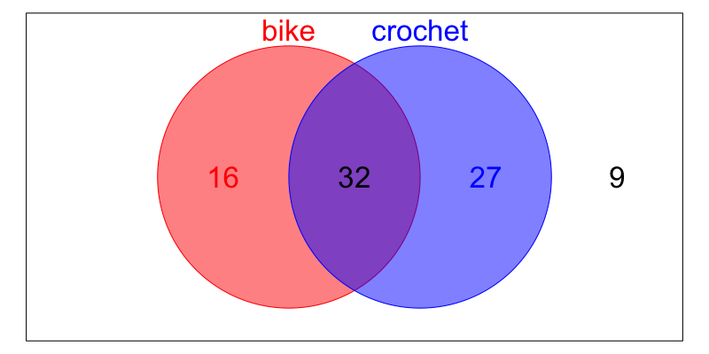

     Let $B$ represent the event that a randomly selected student is in bike club, and let $C$ represent the event that a random student is in crochet club.
     - $P(C)=$
     - $P(B|C)=$
     - $P(B)=$
     - $P(B\cap C)=$
     - $P(B\cup C)=$
     - $P(C|B)=$
     - Are events $B$ and $C$ independent?

#### Solution

#### Question

112. In a school, there are 131 students. Each student can be in bike club, crochet club, both, or neither. The amounts are represented in the Venn diagram below.

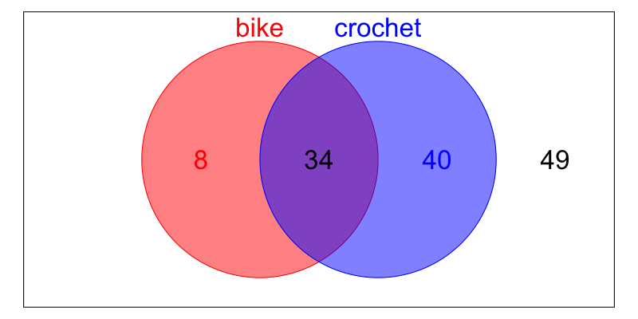

     Let $B$ represent the event that a randomly selected student is in bike club, and let $C$ represent the event that a random student is in crochet club.
     - $P(B|C)=$
     - $P(B\cup C)=$
     - $P(C|B)=$
     - $P(B)=$
     - $P(C)=$
     - $P(B\cap C)=$
     - Are events $B$ and $C$ independent?

#### Solution

#### Question

113. In a school, there are 129 students. Each student can be in bike club, crochet club, both, or neither. The amounts are represented in the Venn diagram below.

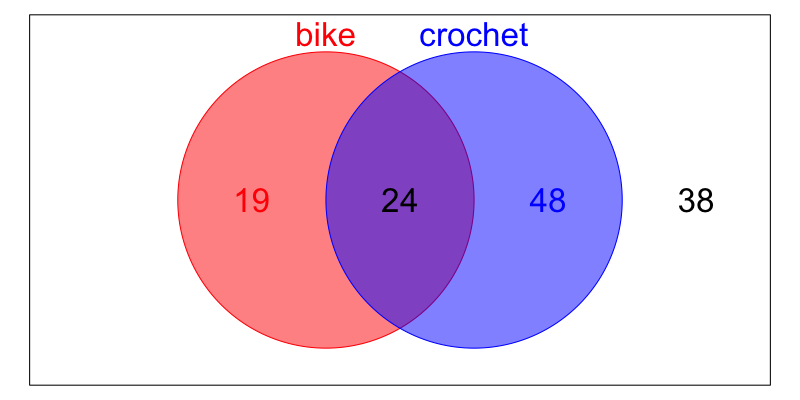

     Let $B$ represent the event that a randomly selected student is in bike club, and let $C$ represent the event that a random student is in crochet club.
     - $P(B\cup C)=$
     - $P(C)=$
     - $P(B\cap C)=$
     - $P(B)=$
     - $P(B|C)=$
     - $P(C|B)=$
     - Are events $B$ and $C$ independent?

#### Solution

#### Question

114. In a school, there are 66 students. Each student can be in bike club, crochet club, both, or neither. The amounts are represented in the Venn diagram below.

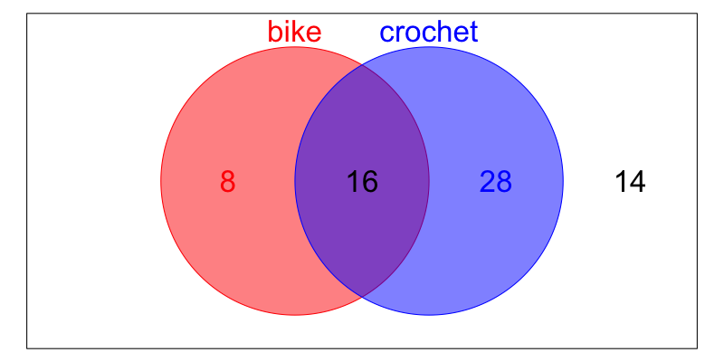

     Let $B$ represent the event that a randomly selected student is in bike club, and let $C$ represent the event that a random student is in crochet club.
     - $P(B\cup C)=$
     - $P(B|C)=$
     - $P(C|B)=$
     - $P(C)=$
     - $P(B)=$
     - $P(B\cap C)=$
     - Are events $B$ and $C$ independent?

#### Solution

#### Question

115. In a school, there are 114 students. Each student can be in bike club, crochet club, both, or neither. The amounts are represented in the Venn diagram below.

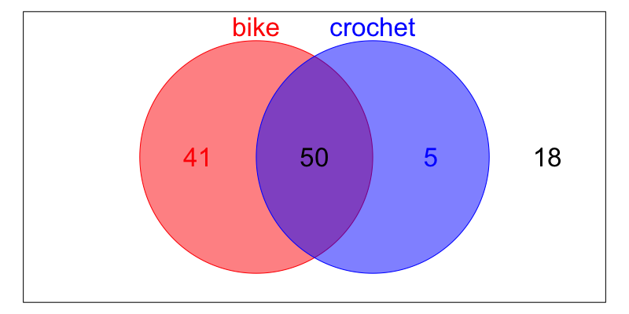

     Let $B$ represent the event that a randomly selected student is in bike club, and let $C$ represent the event that a random student is in crochet club.
     - $P(C|B)=$
     - $P(B\cup C)=$
     - $P(B|C)=$
     - $P(B)=$
     - $P(B\cap C)=$
     - $P(C)=$
     - Are events $B$ and $C$ independent?

#### Solution

#### Question

116. In a school, there are 72 students. Each student can be in bike club, crochet club, both, or neither. The amounts are represented in the Venn diagram below.

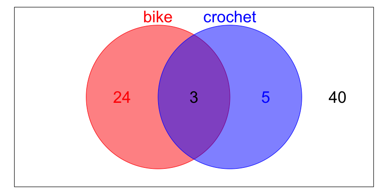

     Let $B$ represent the event that a randomly selected student is in bike club, and let $C$ represent the event that a random student is in crochet club.
     - $P(B|C)=$
     - $P(B)=$
     - $P(B\cup C)=$
     - $P(C)=$
     - $P(C|B)=$
     - $P(B\cap C)=$
     - Are events $B$ and $C$ independent?

#### Solution

#### Question

117. In a school, there are 78 students. Each student can be in bike club, crochet club, both, or neither. The amounts are represented in the Venn diagram below.

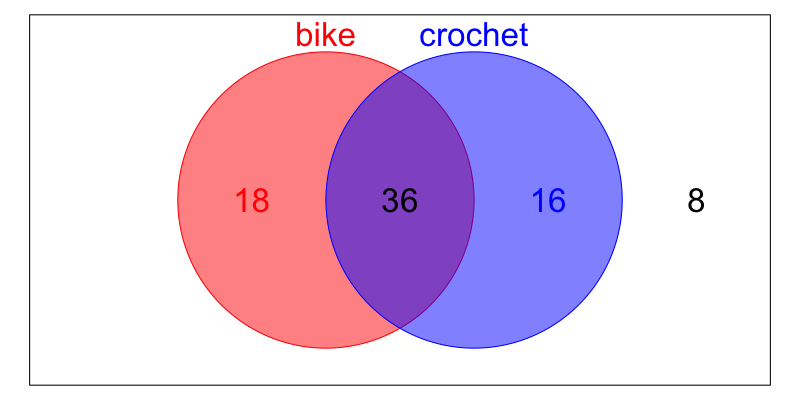

     Let $B$ represent the event that a randomly selected student is in bike club, and let $C$ represent the event that a random student is in crochet club.
     - $P(B\cup C)=$
     - $P(B)=$
     - $P(C|B)=$
     - $P(C)=$
     - $P(B|C)=$
     - $P(B\cap C)=$
     - Are events $B$ and $C$ independent?

#### Solution

#### Question

118. In a school, there are 100 students. Each student can be in bike club, crochet club, both, or neither. The amounts are represented in the Venn diagram below.

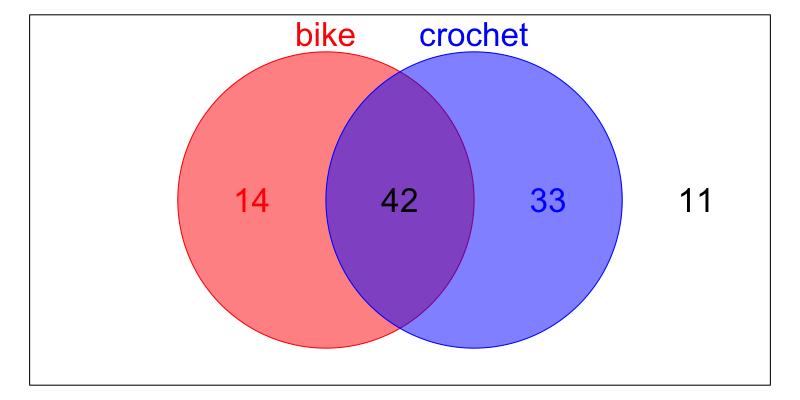

     Let $B$ represent the event that a randomly selected student is in bike club, and let $C$ represent the event that a random student is in crochet club.
     - $P(B|C)=$
     - $P(C|B)=$
     - $P(C)=$
     - $P(B\cup C)=$
     - $P(B\cap C)=$
     - $P(B)=$
     - Are events $B$ and $C$ independent?

#### Solution

#### Question

119. In a school, there are 77 students. Each student can be in bike club, crochet club, both, or neither. The amounts are represented in the Venn diagram below.

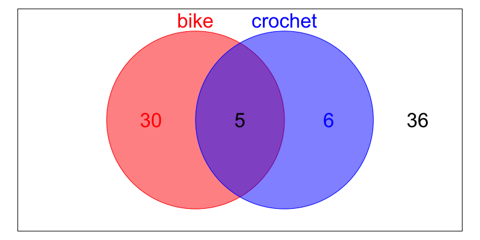

     Let $B$ represent the event that a randomly selected student is in bike club, and let $C$ represent the event that a random student is in crochet club.
     - $P(B\cup C)=$
     - $P(C|B)=$
     - $P(B)=$
     - $P(B\cap C)=$
     - $P(C)=$
     - $P(B|C)=$
     - Are events $B$ and $C$ independent?

#### Solution

#### Question

120. In a school, there are 53 students. Each student can be in bike club, crochet club, both, or neither. The amounts are represented in the Venn diagram below.

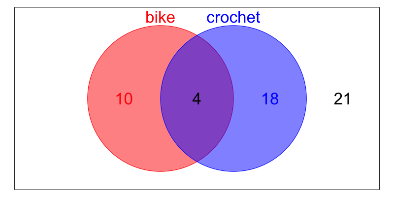

     Let $B$ represent the event that a randomly selected student is in bike club, and let $C$ represent the event that a random student is in crochet club.
     - $P(B\cup C)=$
     - $P(B\cap C)=$
     - $P(C|B)=$
     - $P(B)=$
     - $P(B|C)=$
     - $P(C)=$
     - Are events $B$ and $C$ independent?

#### Solution